# [Optional] Introduction to Computational Thinking & Simulation with R

Christopher Gandrud

2021-03-17

> “What I cannot create, I do not understand” – [Richard Feynman](https://archives.caltech.edu/pictures/1.10-29.jpg)

> “It is immoral to collect data before simulating the hypothesized data generating process.” – Andrew Gelman (what I remember of a comment to the Stanford Causal Inference Seminar in 2020).

## 📝 Lesson Preview

- Why simulate?
- Simple simulation workflow
- Documenting Functions in RMonte Carlo with apply and parallelization
- Debugging in R
- Throughout, we will include examples of how to plot with base R and ggplot2

## Motivation: Why simulate?

We’ve covered many of the basics of programming in R. Let’s bring many of these concepts together to help us better understand our research problems, even before we gather any data. Let’s simulate some **data generating processes (DGP)**.

A data generating process is the process that creates the data in a data set. These processes can include, for example, both the social processes that result in migration data and even unexpected (or undesired) issues in the sampling procedure like non-random study attrition.

Wait, why are we talking about simulating data generating processes in an introduction to R course? There are two sets of reasons.

First, computational generative modeling–simulating data generating processes with a computer–can be a key tool for understanding and evaluating the statistical methods you are using to understand a given data generating process (Gelman, Hill, and Vehtari 2021, 76). Will your chosen statistical model identify the effect you are interested, even if you completely understand the DGP? This is surprisingly often not the case, especially for non-trivial data generating processes. Simulation allows you to stress test your chosen models, with a given assumed DGP, and compare the appropriateness of different models for this DGP.

In Gelman’s strong view stated above, if your identification strategy can’t recover effects in known–simulated data–you shouldn’t waste time and money collecting real world data.

The second reason we are covering statistical simulation, and most importantly for this class, is that simulation requires you to work your new skills as an R programmer. Because the DGP you are working with are probabilistic, you will need to repeat the simulations with the same data generating process to understand the statistical properties. This is called the [Monte Carlo Method](https://en.wikipedia.org/wiki/Monte_Carlo_method). So you will need to write functions, run them efficiently, e.g. sometimes in parallel, transform large amounts of data, and plot the results.

## Simple simulation workflow

A typical simulation workflow looks something like this:

[interactive chart not shown]

We start by hypothesizing what the data generating process we care about might be. Then we propose one or candidate strategies to identify effects in this data generating process, e.g. regression, matching, difference in differences. We begin implementing the simulation fo this DGP-identification strategy by creating function(s) for simulating and analyzing the data for one simulation. Once we have the simulation correctly working for one draw, we create a function(s) to make $n$ draws. We then (usually) examine the results by plotting quantities of interest from the simulations, such as the distribution of some estimate or the error from some ground truth across simulations. Frequently, we learn something unexpected by the end either about our understanding of the data generating process or our candidate identification strategies. So we often need to repeat the process.

Notice that most steps often involve some debugging. We’ll dig debugging into that below. But let’s look at a simple ideal case.

### Example 1: Simple A/B Test Discrete probabilities

Imagine that we want to run an A/B test–randomised control trial–a new treatment to the status quo control treatment. We are interested in the effect of the treatment on whether or not individuals in the study do some action–e.g. vote in an election.[^1] This is a discrete variable. Can we use a difference of means test to estimate the treatment effect?

Let’s start by hypothesizing what the data generating process could be. Imagine that based on prior research we know that their is a baseline probability of the action with the control of 0.1:

$$y \sim \mathrm{Binomial}(0.1)$$
To simulate one draw from this binomial distribution in R use:

```r
control_y_1 <- rbinom(n = 1, size = 1, prob = 0.1)
control_y_1
```

```
## [1] 0
```

Let’s walk through this code. `rbinom()` is the function to randomly (`r`) draw from the binomial distribution (`binom`). `n` is the number of draws for this simulation, `size` is the “number of trials,” basically it means that you want to the “success” outcome to be 1 and 0 otherwise. `prob` is the probability of “success.”

It’s unlikely that we will run an A/B test with only one participant in the control group, let’s go up to 2,000,000[^2] and plot the results.

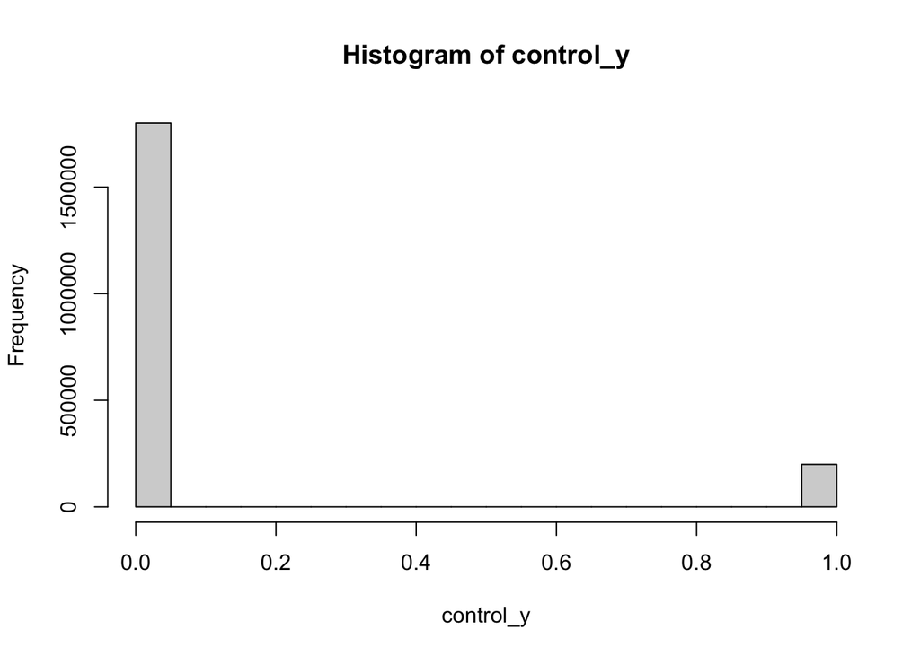

```r
# number of observations variable to ensure consistency across sims
n_obs <- 2e6
control_prob <- 0.1

control_y <- rbinom(n = n_obs, size = 1, prob = control_prob)
hist(control_y)
```

### Side note: Histograms with ggplot2

[ggplot2](https://ggplot2.tidyverse.org/) is a very powerful way to create graphics in R. Here is an example of how you would create a histogram with ggplot2.

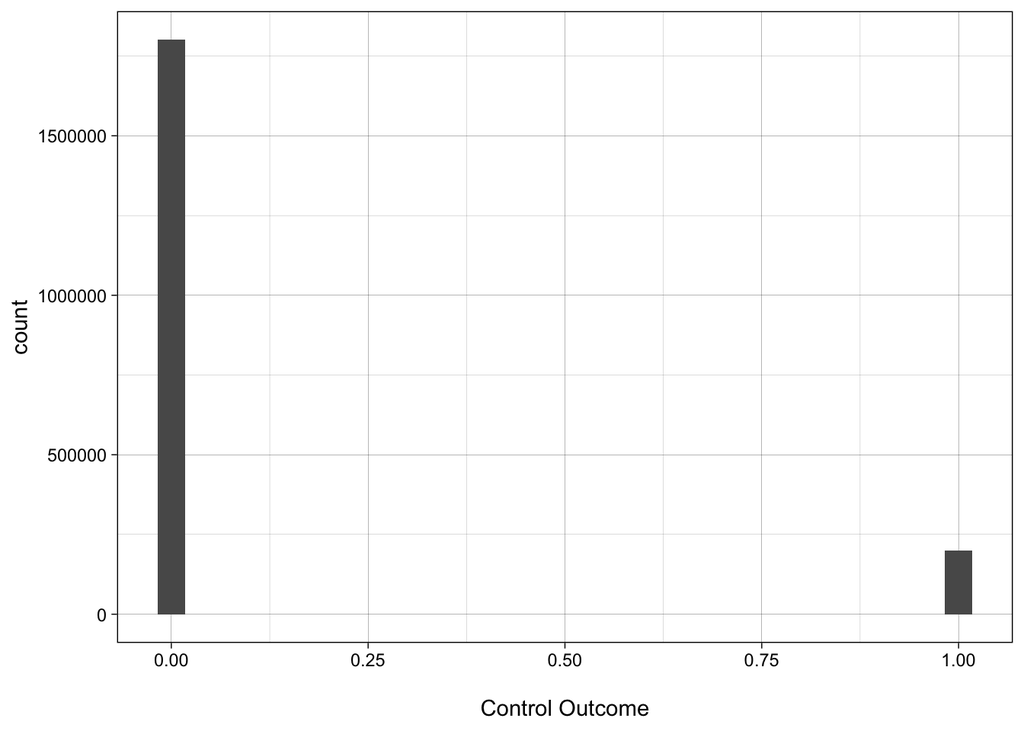

```r
# ggplot2 is a member of the "tidyverse" set of packages
xfun::pkg_attach2("tidyverse")

# I personally enjoy the simplicity of the linedraw theme
theme_set(theme_linedraw())

# ggplot cannot accept a vector, like hist.
# Instead you need to convert to a data frame or the tidyverse equivalent "tibble"
control_y_tbl <- as_tibble(control_y)

# Plot and change the x-axis label
ggplot(control_y_tbl, aes(value)) + # as_tibble names the column "value" by default
  geom_histogram() +
  xlab("\nControl Outcome") # \n adds a line break before the label
```

Ok, we’ve simulated one run of the control group. Now let’s think about the treatment group. Imagine we anticipate that a realistic effect of the treatment–again based on prior knowledge–is an average relative improvement of 1%. We simulate this with:

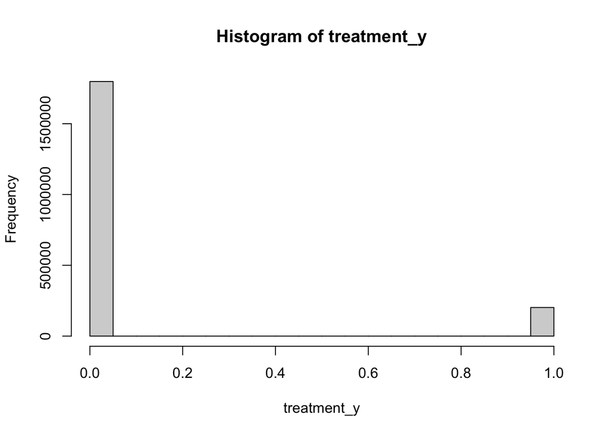

```r
rel_effect <- 0.01
treat_prob <- control_prob + (control_prob * rel_effect)
treatment_y <- rbinom(n = n_obs, size = 1, prob = treat_prob)

hist(treatment_y)
```

Finally, we compare the means of the two groups:

```r
mean(treatment_y) - mean(control_y)
```

```
## [1] 0.001378
```

That’s one simulation. Let’s wrap it up in a function so it will be easy to run $n$ simulations

```r
one_sim <- function(n, control_prob, rel_effect) {
  treat_prob <- control_prob + (control_prob * rel_effect)

  cy <- rbinom(n = n, size = 1, prob = control_prob)
  ty <- rbinom(n = n, size = 1, prob = treat_prob)

  mean(ty) - mean(cy)
}
```

Let’s test it to make sure it works.

```r
one_sim(n = n_obs, control_prob = control_prob,
        rel_effect = rel_effect)
```

```
## [1] 0.0008055
```

This is very close to the true increase of $\frac{\bar{x}_{treat} - \bar{x}_{control}}{\bar{x}_{control}}\cdot100=1\%$.

## Documenting Functions in R

A quick aside: it is important to get in the habit of documenting your functions as you write them. This makes them easier for others (and yourself in the future) to understand.

There are some R documentation conventions to follow.[^3] Function documentation begins with a description of what the function does. Then each function parameter is documented using `@param`. You can also give examples of the function working with `@examples`. All of the documentation should be commented out with `#'`. E.g.

```r
#' Simulate one A/B test outcome from the binomial distribution
#' and return the difference of the means of the two treatment arms.
#'
#' @param n integer number of observations per treatment arm
#' @param control_prob numeric probability of success in the control group
#' @param rel_effect numeric relative effect of the treatment compared
#' to the control

one_sim <- function(n, control_prob, rel_effect) {
  treat_prob <- control_prob + (control_prob * rel_effect)

  cy <- rbinom(n = n, size = 1, prob = control_prob)
  ty <- rbinom(n = n, size = 1, prob = treat_prob)

  mean(ty) - mean(cy)
}
```

### Monte Carlo with `for`

```r
# package to add a progress bar to monitor loop progress
xfun::pkg_attach2("progress")

# Create vector of NAs to take the simulation results
n_sims <- 100
mean_diff <- rep(NA, n_sims)
pb <- progress_bar$new(total = n_sims)

for (i in seq_along(mean_diff)) {
  pb$tick() # increment the progress bar
  mean_diff[i] <- one_sim(n = n_obs, control_prob = control_prob,
        rel_effect = rel_effect)
}
```

[output not shown]

[output cut: 43 more lines]

[output not shown]

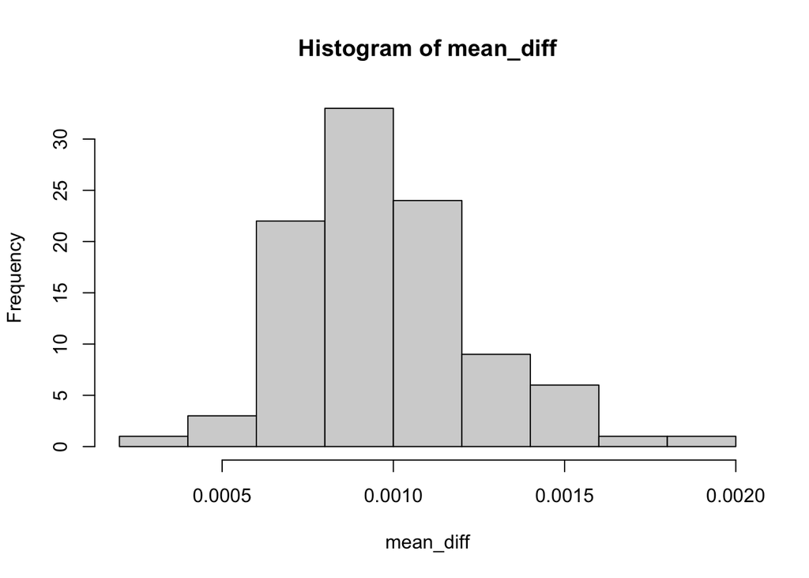

```r
hist(mean_diff)
```